# Reproducible Research: Peer Assessment 1

HowlinHank

August 16, 2015

This work is for the Peer Assessment 1 for the Aug 2015 Reproducible Research class taught by Roger Peng as part of Coursera’s Data Science Specialization.

The data for this exercise is taken from the assignment github repository but can also be found at [link](https://d396qusza40orc.cloudfront.net/repdata%2Fdata%2Factivity.zip)

The work will use dplyr and ggplot2. Loading these silently.

Figures that are created will be stored in the figure directory in png format at 600x600 resolution.

## Loading and preprocessing the data ======================

Check the activity.csv file to see whether it has a header and what separator it uses

```r
setwd("~/rdata/ReproRes-Proj1/RepData_PeerAssessment1")
figdir <- "~/rdata/ReproRes-Proj1/RepData_PeerAssessment1/figures/"
readLines("activity.csv", n=4)
```

```
## [1] "\"steps\",\"date\",\"interval\"" "NA,\"2012-10-01\",0"
## [3] "NA,\"2012-10-01\",5"             "NA,\"2012-10-01\",10"
```

The data was loaded from the local file system and stored in a data frame. I will convert the date field to a Date format.

```r
cls <- c("steps"="numeric", "date"="character", "interval"="numeric")
rawdata <-read.csv("activity.csv", header=TRUE, colClasses=cls)
rawdata$date <- as.Date(rawdata$date, "%Y-%m-%d")
str(rawdata)
```

```
## 'data.frame':    17568 obs. of  3 variables:
##  $ steps   : num  NA NA NA NA NA NA NA NA NA NA ...
##  $ date    : Date, format: "2012-10-01" "2012-10-01" ...
##  $ interval: num  0 5 10 15 20 25 30 35 40 45 ...
```

## What is mean total number of steps taken per day? =========

```r
steps_per_day <- rawdata %>% group_by(date) %>% summarize(steps_per_day= sum(steps))
filename <- "1_steps_per_day_hist.png"
steps_per_day_fig <- paste(figdir, filename, sep="")
png(filename = steps_per_day_fig, width=600, height=600)
g <-qplot(data=steps_per_day, steps_per_day, geom="histogram")
g
```

```
## stat_bin: binwidth defaulted to range/30. Use 'binwidth = x' to adjust this.
```

```r
dev.off()
```

```r
g
```

```
## stat_bin: binwidth defaulted to range/30. Use 'binwidth = x' to adjust this.
```

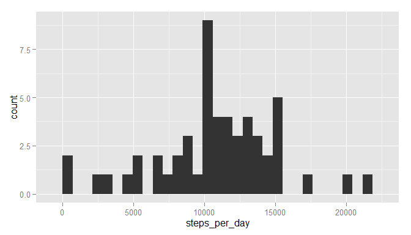

```r
mean_day <- mean(steps_per_day$steps_per_day, na.rm=TRUE)
median_day <- median(steps_per_day$steps_per_day, na.rm=TRUE)
```

### Results ——————————-

The histogram is stored in the file: **figures/1_steps_per_day_hist.png**

## What is the average daily activity pattern? ================

```r
int_steps <- rawdata %>% group_by(interval) %>% summarise(daily_ave = mean(steps, na.rm=TRUE))
filename <- "2_ave_daily.png"
ave_daily_fig <- paste(figdir, filename, sep="")
png(filename = ave_daily_fig, width=600, height=600)
g <- qplot(interval, daily_ave, data=int_steps, geom=c("point","smooth"), stat="identity",
           color="red", fill = "red") +
    xlab("5 minute intervals throughout day starting after midnight") +
    ylab("Average daily steps") +
    ggtitle("Average daily steps per 5 min interval")
g
dev.off()
```

```r
g
```

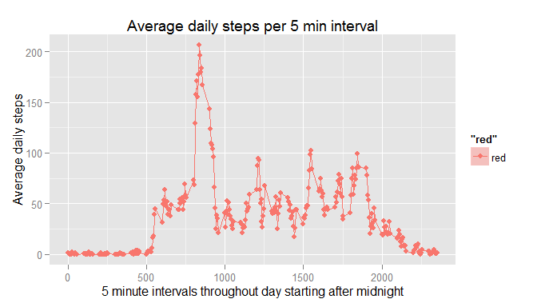

```r
max_steps <- max(int_steps$daily_ave)
max_day <- which.max(int_steps$daily_ave)
hour <- trunc(max_day/12)
min <- (max_day * 5) %% 60
```

### Results ————

The maximum number of steps is: **206.1698113**

The graph is stored in the file: **figures/2_ave_daily.png**